# Reddit_Corona_Topics

### This notebook primarily focuses on analysing the all the threads and comments under https://www.reddit.com/r/Coronavirus/.

The notebook consists of 8 major parts. You can jump to each of these sections by clicking on the links:

1. Extraction of the relevant data feilds using the Python Reddit API Wrapper

2. Cleaning of the text columns and export the data to a json file

3. Pre-processing the data for topic modelling and frequent words analysis which includes stop words removal, stemming, lemmatizing etc,.

4. Building corpus using Bag of words

5. Building corpus using TF-IDF

6. Plotting two LDA visualizations on the two corpuses

7. Additional visualisations on the topic modelling

8. A simple word cloud based on frequently used words

##### Importing packages

```python
#! usr/bin/env python3
#!pip install praw
import praw
import pandas as pd
import datetime as dt
```

##### Connection to the Reddit API

```python
#You can create an app on Reddit and generate these credentials for your API
reddit = praw.Reddit(client_id='IAFVrIOB_HKgrg', \
                     client_secret='7F_EsTNiGtseqtHMp2gHmSuUYbo', \
                     user_agent='corona', \
                     username='aruvidsouza', \
                     password='Reddit@1')
```

```python
reddit.read_only = True
```

```python
subreddit = reddit.subreddit('Coronavirus')
```

```python
for submission in subreddit.hot(limit=3):
    print(submission.title)  # Output: the submission's title
    print(submission.score)  # Output: the submission's score
    print(submission.id)     # Output: the submission's ID
    print(submission.url)
```

```
Daily Discussion Post - April 13 | Questions, images, videos, comments, unconfirmed reports, theories, suggestions
138
g0jcbi
https://www.reddit.com/r/Coronavirus/comments/g0jcbi/daily_discussion_post_april_13_questions_images/
Scientific Studies Looking For Participants
5147
fux5z5
https://www.reddit.com/r/Coronavirus/comments/fux5z5/scientific_studies_looking_for_participants/
Virginia pastor who defiantly held church service dies of coronavirus
49896
g0rbav
https://dnyuz.com/2020/04/13/virginia-pastor-who-defiantly-held-church-service-dies-of-coronavirus/
```

```python
top_subreddit = subreddit.top(limit=100000)
```

```python
top_subreddit
```

```
<praw.models.listing.generator.ListingGenerator at 0x172306a24c8>
```

```python
comm_list = []
header_list = []
i = 0
for submission in reddit.subreddit('Coronavirus').hot(limit=2):
    submission.comments.replace_more(limit=None)
    comment_queue = submission.comments[:]
```

```python
for submission in subreddit.top(limit=1):
    print(submission.title, submission.id)
```

```
Even if COVID-19 is unavoidable, delaying infections can flatten the peak number of illnesses to within hospital capacity and significantly reduce deaths. fgi2pi
```

```python
topics_dict = { "title":[], "score":[], "id":[], "url":[],"comms_num": [],"created": [], "body":[], "comments" :[]}
```

```python
def convert(s):
    new = ""
    for x in s:
        new += x
    return new
```

```python
for submission in top_subreddit:
    topics_dict["title"].append(submission.title)
    topics_dict["score"].append(submission.score)
    topics_dict["id"].append(submission.id)
    topics_dict["url"].append(submission.url)
    topics_dict["comms_num"].append(submission.num_comments)
    topics_dict["created"].append(submission.created)
    topics_dict["body"].append(submission.selftext)
    tlist=[]
    for top_level_comment in submission.comments:

        try:
            tlist.append(top_level_comment.body)
        except:
            tlist.append("")
    comments = convert(tlist)
    topics_dict["comments"].append(comments)
```

```python
corona_data = pd.DataFrame(topics_dict)
```

```python
corona_data.head(2)
```

|  | title | score | id | url | comms_num | created | body | comments |
| --- | --- | --- | --- | --- | --- | --- | --- | --- |
| 0 | Even if COVID-19 is unavoidable, delaying infe... | 128122 | fgi2pi | https://thespinoff.co.nz/wp-content/uploads/20... | 4407 | 1.583892e+09 |  | Welcome to r/Coronavirus! We have a very speci... |
| 1 | Gino Fasoli was 73 years old. He was italian a... | 117088 | fn1mtn | https://www.corriere.it/cronache/20_marzo_21/c... | 1826 | 1.584921e+09 |  | Welcome to r/Coronavirus! We have a very speci... |

```python
def get_date(created):
    return dt.datetime.fromtimestamp(created)
```

```python
_timestamp = corona_data["created"].apply(get_date)
```

```python
corona_data = corona_data.assign(timestamp = _timestamp)
```

```python
corona_data.head(2)
```

|  | title | score | id | url | comms_num | created | body | comments | timestamp |
| --- | --- | --- | --- | --- | --- | --- | --- | --- | --- |
| 0 | Even if COVID-19 is unavoidable, delaying infe... | 128122 | fgi2pi | https://thespinoff.co.nz/wp-content/uploads/20... | 4407 | 1.583892e+09 |  | Welcome to r/Coronavirus! We have a very speci... | 2020-03-10 22:04:01 |
| 1 | Gino Fasoli was 73 years old. He was italian a... | 117088 | fn1mtn | https://www.corriere.it/cronache/20_marzo_21/c... | 1826 | 1.584921e+09 |  | Welcome to r/Coronavirus! We have a very speci... | 2020-03-22 19:41:45 |

```python
corona_data=corona_data.drop('created',axis=1)
```

##### Cleaning the columns to export the cleaned data to a json file

```python
corona_data.columns
corona_data_clean = corona_data
```

```python
def clean_text(df, text_field):

    '''
    Clean all the text data within a certain text column of the dataFrame.
    '''
    df[text_field] = df[text_field].str.replace(r"http\S+", " ")
    df[text_field] = df[text_field].str.replace(r"&[a-z]{2,4};", "")
    df[text_field] = df[text_field].str.replace("\\n", " ")
    df[text_field] = df[text_field].str.replace(r"#f", "")
    df[text_field] = df[text_field].str.replace(r"[\’\'\`\":]", "")
    df[text_field] = df[text_field].str.replace(r"[^A-Za-z0-9]", " ")
    df[text_field] = df[text_field].str.replace(r" +", " ")
    df[text_field] = df[text_field].str.lower()
```

```python
corona_data.columns
```

```
Index(['title', 'score', 'id', 'url', 'comms_num', 'body', 'comments',
       'timestamp'],
      dtype='object')
```

```python
clean_text(corona_data_clean, 'title')
clean_text(corona_data_clean, 'body')
clean_text(corona_data_clean, 'comments')
```

```python
corona_data_clean.head(5)
```

|  | title | score | id | url | comms_num | body | comments | timestamp |
| --- | --- | --- | --- | --- | --- | --- | --- | --- |
| 0 | even if covid 19 is unavoidable delaying infec... | 128122 | fgi2pi | https://thespinoff.co.nz/wp-content/uploads/20... | 4407 |  | welcome to r coronavirus we have a very specif... | 2020-03-10 22:04:01 |
| 1 | gino fasoli was 73 years old he was italian an... | 117088 | fn1mtn | https://www.corriere.it/cronache/20_marzo_21/c... | 1826 |  | welcome to r coronavirus we have a very specif... | 2020-03-22 19:41:45 |
| 2 | how to stop a virus from spreading | 104533 | fn3j0w | https://thespinoff.co.nz/wp-content/uploads/20... | 2207 |  | welcome to r coronavirus we have a very specif... | 2020-03-22 21:38:24 |
| 3 | all 11 coronavirus patients in greenland have ... | 100809 | fxdwoa | https://nun.gl/Emner/Borgere/Coronavirus_emne/... | 2316 |  | just like the simulationsif plague inc has tau... | 2020-04-09 00:14:57 |
| 4 | an italian hospital ran out of icu valves a lo... | 99620 | fjcz60 | https://twitter.com/michalnaka/status/12393162... | 1426 |  | welcome to r coronavirus we have a very specif... | 2020-03-16 05:52:17 |

```python
corona_data_clean.shape
```

```
(975, 8)
```

```python
#removing the noisy rows in the data
corona_data_clean = corona_data_clean[corona_data_clean['id'].astype(str).str.startswith('f')]
```

```python
corona_data_clean.shape
```

```
(961, 8)
```

##### Exporting cleaned data to a json file

```python
corona_data_clean.to_json(r'corona_reddit.json')
```

## LDA

##### LDA needs to be done only on the text columns. Hence we drop the rest of the columns and concatenate the text columns we have

```python
corona_data_LDA = corona_data_clean[['title', 'body', 'comments']]
```

```python
corona_data_LDA['text']= corona_data_LDA['title'] + corona_data_LDA['body'] + corona_data_LDA['comments']
corona_data_LDA = corona_data_LDA[['text']]
```

```python
corona_data_LDA.head(5)
```

|  | text |
| --- | --- |
| 0 | even if covid 19 is unavoidable delaying infec... |
| 1 | gino fasoli was 73 years old he was italian an... |
| 2 | how to stop a virus from spreadingwelcome to r... |
| 3 | all 11 coronavirus patients in greenland have ... |
| 4 | an italian hospital ran out of icu valves a lo... |

### Data Pre-processing

We will perform the following steps:

Tokenization: Split the text into sentences and the sentences into words. Lowercase the words and remove punctuation.

All stopwords are removed.

Words are lemmatized — words in third person are changed to first person and verbs in past and future tenses are changed into present.

Words are stemmed — words are reduced to their root form

### Loading gensim and nltk libraries

```python
import gensim
from gensim.utils import simple_preprocess
from gensim.parsing.preprocessing import STOPWORDS
from nltk.stem import WordNetLemmatizer, SnowballStemmer
from nltk.stem.porter import *
import numpy as np
np.random.seed(2018)
import nltk
nltk.download('wordnet')
```

```
True
```

```python
stemmer = PorterStemmer()
def lemmatize_stemming(text):
    return stemmer.stem(WordNetLemmatizer().lemmatize(text, pos='v'))
def preprocess(text):
    result = []
    for token in gensim.utils.simple_preprocess(text):
        if token not in gensim.parsing.preprocessing.STOPWORDS and len(token) > 3:
            result.append(lemmatize_stemming(token))
    return result
```

##### Preprocess the text, saving the results as ‘processed_docs’

```python
processed_docs = corona_data_LDA['text'].map(preprocess)
processed_docs[:10]
```

```
0    [covid, unavoid, delay, infect, flatten, peak,...
1    [gino, fasoli, year, italian, famili, doctor, ...
2    [stop, viru, coronaviru, specif, rule, highlig...
3    [coronaviru, patient, greenland, recov, affect...
4    [italian, hospit, valv, local, bring, printer,...
5    [mark, cuban, say, bail, compani, allow, stock...
6    [governor, cuomo, mother, expend, mother, expe...
7    [let, clear, viru, spread, spread, stay, home,...
8    [year, bear, spanish, beat, covid, italybig, g...
9    [starbuck, employe, beg, compani, shut, store,...
Name: text, dtype: object
```

### Bag of Words

Create a dictionary from ‘processed_docs’ containing the number of times a word appears in the training set.

```python
dictionary = gensim.corpora.Dictionary(processed_docs)
count = 0
for k, v in dictionary.iteritems():
    print(k, v)
    count += 1
    if count > 10:
        break
```

```
0 abil
1 accept
2 accid
3 account
4 accus
5 ach
6 action
7 activ
8 actual
9 addit
10 admin
```

#### Filter out tokens that appear in

less than 10 documents (absolute number) or more than 0.5 documents (fraction of total corpus size, not absolute number). after the above two steps, keep only the first 100000 most frequent tokens.

```python
dictionary.filter_extremes(no_below=10, no_above=0.5, keep_n=100000)
```

#### Gensim doc2bow

For each document we create a dictionary reporting how many words and how many times those words appear. Save this to ‘bow_corpus’, then check our selected document earlier.

```python
bow_corpus = [dictionary.doc2bow(doc) for doc in processed_docs]
```

#### Preview Bag Of Words for our sample preprocessed document

```python
bow_doc_310 = bow_corpus[310]
for i in range(5):
    print("Word {} (\"{}\") appears {} time.".format(bow_doc_310[i][0],
                                               dictionary[bow_doc_310[i][0]],
bow_doc_310[i][1]))
```

```
Word 0 ("abil") appears 1 time.
Word 4 ("activ") appears 1 time.
Word 5 ("addit") appears 1 time.
Word 10 ("amaz") appears 2 time.
Word 12 ("anim") appears 1 time.
```

### TF-IDF

```python
from gensim import corpora, models
tfidf = models.TfidfModel(bow_corpus)
corpus_tfidf = tfidf[bow_corpus]
```

#### Running LDA using Bag of Words

```python
ldamodel = gensim.models.LdaMulticore(bow_corpus, num_topics=10, id2word=dictionary, passes=2, workers=2)
```

```python
ldamodel.save('model_combined.gensim')
topics = ldamodel.print_topics(num_words=4)
for topic in topics:
   print(topic)
```

```
(0, '0.008*"symptom" + 0.007*"itali" + 0.004*"rate" + 0.004*"confirm"')
(1, '0.008*"patient" + 0.007*"ventil" + 0.006*"compani" + 0.005*"price"')
(2, '0.006*"school" + 0.005*"florida" + 0.004*"worker" + 0.003*"patient"')
(3, '0.005*"taiwan" + 0.004*"open" + 0.004*"itali" + 0.003*"essenti"')
(4, '0.014*"wear" + 0.007*"symptom" + 0.004*"protect" + 0.004*"patient"')
(5, '0.006*"itali" + 0.004*"game" + 0.003*"school" + 0.003*"play"')
(6, '0.012*"store" + 0.011*"worker" + 0.011*"essenti" + 0.007*"employe"')
(7, '0.004*"water" + 0.004*"play" + 0.004*"patient" + 0.004*"itali"')
(8, '0.007*"vaccin" + 0.005*"compani" + 0.004*"chines" + 0.003*"donat"')
(9, '0.009*"compani" + 0.008*"worker" + 0.007*"nurs" + 0.006*"employe"')
```

```python
for idx, topic in ldamodel.print_topics(-1):
    print('Topic: {} \nWords: {}'.format(idx, topic))
```

```
Topic: 0
Words: 0.008*"symptom" + 0.007*"itali" + 0.004*"rate" + 0.004*"confirm" + 0.004*"patient" + 0.003*"result" + 0.003*"travel" + 0.003*"neg" + 0.003*"nurs" + 0.003*"popul"
Topic: 1
Words: 0.008*"patient" + 0.007*"ventil" + 0.006*"compani" + 0.005*"price" + 0.004*"servic" + 0.004*"lose" + 0.004*"worker" + 0.003*"amazon" + 0.003*"distanc" + 0.003*"essenti"
Topic: 2
Words: 0.006*"school" + 0.005*"florida" + 0.004*"worker" + 0.003*"patient" + 0.003*"shut" + 0.003*"open" + 0.003*"student" + 0.003*"kid" + 0.003*"beach" + 0.003*"compani"
Topic: 3
Words: 0.005*"taiwan" + 0.004*"open" + 0.004*"itali" + 0.003*"essenti" + 0.003*"presid" + 0.003*"patient" + 0.003*"economi" + 0.003*"shut" + 0.003*"travel" + 0.003*"effect"
Topic: 4
Words: 0.014*"wear" + 0.007*"symptom" + 0.004*"protect" + 0.004*"patient" + 0.004*"kid" + 0.003*"worker" + 0.003*"cough" + 0.003*"distanc" + 0.003*"outsid" + 0.003*"lockdown"
Topic: 5
Words: 0.006*"itali" + 0.004*"game" + 0.003*"school" + 0.003*"play" + 0.003*"diseas" + 0.003*"store" + 0.003*"distanc" + 0.003*"market" + 0.003*"wish" + 0.003*"immun"
Topic: 6
Words: 0.012*"store" + 0.011*"worker" + 0.011*"essenti" + 0.007*"employe" + 0.007*"compani" + 0.006*"groceri" + 0.005*"jeff" + 0.005*"suppli" + 0.005*"food" + 0.005*"open"
Topic: 7
Words: 0.004*"water" + 0.004*"play" + 0.004*"patient" + 0.004*"itali" + 0.004*"game" + 0.003*"compani" + 0.003*"citi" + 0.003*"repeat" + 0.003*"free" + 0.003*"chines"
Topic: 8
Words: 0.007*"vaccin" + 0.005*"compani" + 0.004*"chines" + 0.003*"donat" + 0.003*"gate" + 0.003*"market" + 0.003*"presid" + 0.003*"fight" + 0.003*"diseas" + 0.002*"hero"
Topic: 9
Words: 0.009*"compani" + 0.008*"worker" + 0.007*"nurs" + 0.006*"employe" + 0.005*"pay" + 0.004*"food" + 0.004*"patient" + 0.004*"healthcar" + 0.003*"rent" + 0.003*"symptom"
```

```python
get_document_topics = ldamodel.get_document_topics(bow_corpus[0])
print(get_document_topics)
```

```
[(0, 0.6195826), (2, 0.17528544), (4, 0.07513851), (5, 0.1065186), (9, 0.017434342)]
```

#### Visualizing topics obtained with Bag or words using pyLDAvis:

```python
import pyLDAvis.gensim
pyLDAvis.enable_notebook()
vis = pyLDAvis.gensim.prepare(ldamodel, bow_corpus, dictionary=ldamodel.id2word)
vis
```

[interactive chart not shown]

#### Running LDA using TF-IDF

```python
lda_model_tfidf = gensim.models.LdaMulticore(corpus_tfidf, num_topics=10, id2word=dictionary, passes=2, workers=4)
for idx, topic in lda_model_tfidf.print_topics(-1):
    print('Topic: {} Word: {}'.format(idx, topic))
```

```
Topic: 0 Word: 0.002*"amazon" + 0.002*"fauci" + 0.002*"employe" + 0.002*"wear" + 0.002*"vaccin" + 0.002*"compani" + 0.002*"worker" + 0.002*"ventil" + 0.002*"store" + 0.001*"essenti"
Topic: 1 Word: 0.003*"landlord" + 0.003*"gamestop" + 0.002*"rent" + 0.002*"wed" + 0.002*"easter" + 0.002*"school" + 0.002*"taiwan" + 0.001*"nurs" + 0.001*"evict" + 0.001*"store"
Topic: 2 Word: 0.002*"ventil" + 0.001*"patient" + 0.001*"itali" + 0.001*"hero" + 0.001*"young" + 0.001*"ford" + 0.001*"flight" + 0.001*"compani" + 0.001*"chines" + 0.001*"travel"
Topic: 3 Word: 0.002*"recov" + 0.002*"player" + 0.001*"celebr" + 0.001*"gamestop" + 0.001*"wave" + 0.001*"symptom" + 0.001*"game" + 0.001*"jazz" + 0.001*"queen" + 0.001*"lockdown"
Topic: 4 Word: 0.001*"employe" + 0.001*"essenti" + 0.001*"starbuck" + 0.001*"symptom" + 0.001*"school" + 0.001*"store" + 0.001*"recov" + 0.001*"worker" + 0.001*"pay" + 0.001*"compani"
Topic: 5 Word: 0.003*"taiwan" + 0.002*"donat" + 0.001*"insur" + 0.001*"result" + 0.001*"wear" + 0.001*"store" + 0.001*"cuomo" + 0.001*"symptom" + 0.001*"pizza" + 0.001*"patient"
Topic: 6 Word: 0.002*"game" + 0.002*"plagu" + 0.001*"march" + 0.001*"store" + 0.001*"neg" + 0.001*"chines" + 0.001*"elderli" + 0.001*"groceri" + 0.001*"korea" + 0.001*"confirm"
Topic: 7 Word: 0.001*"patient" + 0.001*"internet" + 0.001*"donat" + 0.001*"jack" + 0.001*"nurs" + 0.001*"symptom" + 0.001*"itali" + 0.001*"gun" + 0.001*"reddit" + 0.001*"wear"
Topic: 8 Word: 0.003*"itali" + 0.002*"church" + 0.002*"wear" + 0.002*"anim" + 0.002*"italian" + 0.002*"fauci" + 0.002*"market" + 0.001*"compani" + 0.001*"ventil" + 0.001*"presid"
Topic: 9 Word: 0.002*"beach" + 0.002*"navi" + 0.002*"captain" + 0.002*"ventil" + 0.001*"price" + 0.001*"prison" + 0.001*"symptom" + 0.001*"amazon" + 0.001*"chines" + 0.001*"surviv"
```

#### Visualizing topics obtained with TF-IDF using pyLDAvis:

```python
pyLDAvis.enable_notebook()
vis = pyLDAvis.gensim.prepare(lda_model_tfidf, corpus_tfidf, dictionary=ldamodel.id2word)
vis
```

[interactive chart not shown]

#### Addtional Visualisations on the topics obtained

```python
# 1. Wordcloud of Top N words in each topic
from matplotlib import pyplot as plt
from wordcloud import WordCloud, STOPWORDS
import matplotlib.colors as mcolors

cols = [color for name, color in mcolors.TABLEAU_COLORS.items()]  # more colors: 'mcolors.XKCD_COLORS'

cloud = WordCloud(
                  background_color='white',
                  width=2500,
                  height=1800,
                  max_words=10,
                  colormap='tab10',
                  color_func=lambda *args, **kwargs: cols[i],
                  prefer_horizontal=1.0)

topics = lda_model_tfidf.show_topics(formatted=False)

fig, axes = plt.subplots(2, 2, figsize=(10,10), sharex=True, sharey=True)

for i, ax in enumerate(axes.flatten()):
    fig.add_subplot(ax)
    topic_words = dict(topics[i][1])
    cloud.generate_from_frequencies(topic_words, max_font_size=300)
    plt.gca().imshow(cloud)
    plt.gca().set_title('Topic ' + str(i), fontdict=dict(size=16))
    plt.gca().axis('off')


plt.subplots_adjust(wspace=0, hspace=0)
plt.axis('off')
plt.margins(x=0, y=0)
plt.tight_layout()
plt.show()
```

[output not shown]

```python
def format_topics_sentences(ldamodel=None, corpus=None, texts= ','.join((corona_data_LDA['text'].values))):
    # Init output
    sent_topics_df = pd.DataFrame()

    # Get main topic in each document
    for i, row_list in enumerate(ldamodel[corpus]):
        row = row_list[0] if ldamodel.per_word_topics else row_list
        # print(row)
        row = sorted(row, key=lambda x: (x[1]), reverse=True)
        # Get the Dominant topic, Perc Contribution and Keywords for each document
        for j, (topic_num, prop_topic) in enumerate(row):
            if j == 0:  # => dominant topic
                wp = ldamodel.show_topic(topic_num)
                topic_keywords = ", ".join([word for word, prop in wp])
                sent_topics_df = sent_topics_df.append(pd.Series([int(topic_num), round(prop_topic,4), topic_keywords]), ignore_index=True)
            else:
                break
    sent_topics_df.columns = ['Dominant_Topic', 'Perc_Contribution', 'Topic_Keywords']

    # Add original text to the end of the output
    contents = pd.Series(texts)
    sent_topics_df = pd.concat([sent_topics_df, contents], axis=1)
    return(sent_topics_df)


df_topic_sents_keywords = format_topics_sentences(ldamodel=lda_model_tfidf, corpus=corpus_tfidf, texts= ','.join((corona_data_LDA['text'].values)))

# Format
df_dominant_topic = df_topic_sents_keywords.reset_index()
df_dominant_topic.columns = ['Document_No', 'Dominant_Topic', 'Topic_Perc_Contrib', 'Keywords','text']
df_dominant_topic = df_dominant_topic[['Document_No', 'Dominant_Topic', 'Topic_Perc_Contrib', 'Keywords']]
df_dominant_topic.head(10)
```

|  | Document_No | Dominant_Topic | Topic_Perc_Contrib | Keywords |
| --- | --- | --- | --- | --- |
| 0 | 0 | 4.0 | 0.9486 | employe, essenti, starbuck, symptom, school, s... |
| 1 | 1 | 4.0 | 0.5035 | employe, essenti, starbuck, symptom, school, s... |
| 2 | 2 | 4.0 | 0.7218 | employe, essenti, starbuck, symptom, school, s... |
| 3 | 3 | 6.0 | 0.7988 | game, plagu, march, store, neg, chines, elderl... |
| 4 | 4 | 0.0 | 0.4585 | amazon, fauci, employe, wear, vaccin, compani,... |
| 5 | 5 | 8.0 | 0.6695 | itali, church, wear, anim, italian, fauci, mar... |
| 6 | 6 | 4.0 | 0.5942 | employe, essenti, starbuck, symptom, school, s... |
| 7 | 7 | 4.0 | 0.5534 | employe, essenti, starbuck, symptom, school, s... |
| 8 | 8 | 2.0 | 0.7317 | ventil, patient, itali, hero, young, ford, fli... |
| 9 | 9 | 4.0 | 0.8952 | employe, essenti, starbuck, symptom, school, s... |

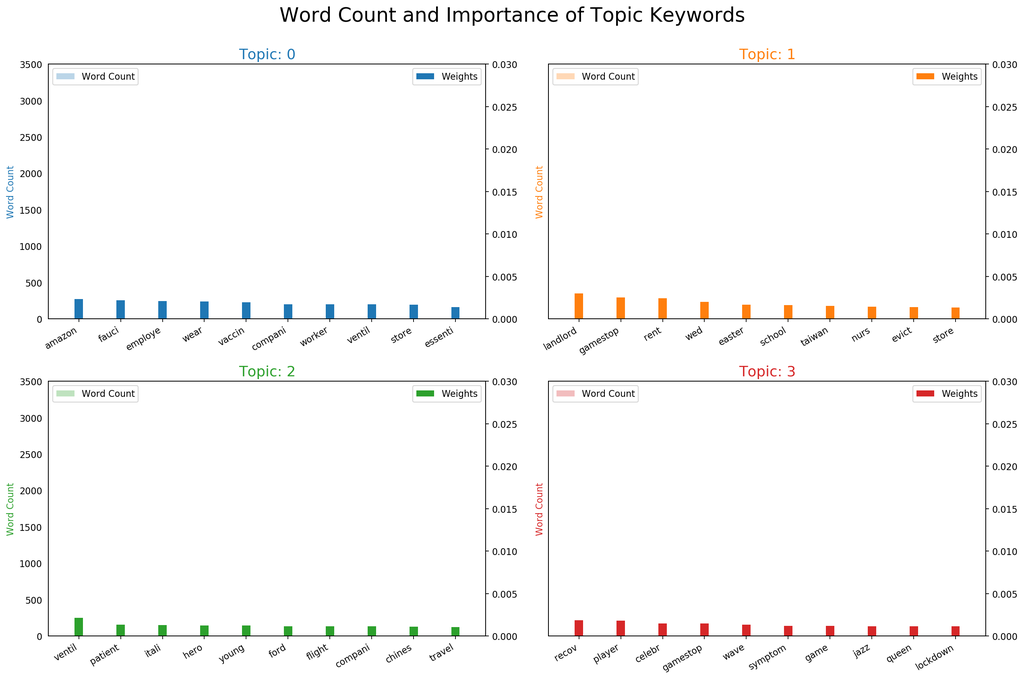

```python
data_ready = ','.join((corona_data_LDA['text'].values))
from collections import Counter
topics = lda_model_tfidf.show_topics(formatted=False)
data_flat = [w for w_list in data_ready for w in w_list]
counter = Counter(data_flat)

out = []
for i, topic in topics:
    for word, weight in topic:
        out.append([word, i , weight, counter[word]])

df = pd.DataFrame(out, columns=['word', 'topic_id', 'importance', 'word_count'])

# Plot Word Count and Weights of Topic Keywords
fig, axes = plt.subplots(2, 2, figsize=(16,10), sharey=True, dpi=160)
cols = [color for name, color in mcolors.TABLEAU_COLORS.items()]
for i, ax in enumerate(axes.flatten()):
    ax.bar(x='word', height="word_count", data=df.loc[df.topic_id==i, :], color=cols[i], width=0.5, alpha=0.3, label='Word Count')
    ax_twin = ax.twinx()
    ax_twin.bar(x='word', height="importance", data=df.loc[df.topic_id==i, :], color=cols[i], width=0.2, label='Weights')
    ax.set_ylabel('Word Count', color=cols[i])
    ax_twin.set_ylim(0, 0.030); ax.set_ylim(0, 3500)
    ax.set_title('Topic: ' + str(i), color=cols[i], fontsize=16)
    ax.tick_params(axis='y', left=False)
    ax.set_xticklabels(df.loc[df.topic_id==i, 'word'], rotation=30, horizontalalignment= 'right')
    ax.legend(loc='upper left'); ax_twin.legend(loc='upper right')

fig.tight_layout(w_pad=2)
fig.suptitle('Word Count and Importance of Topic Keywords', fontsize=22, y=1.05)
plt.show()
```

### Word cloud

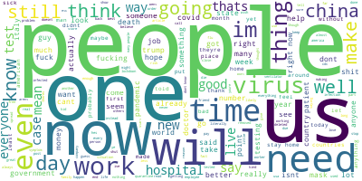

```python
# Import the wordcloud library
from wordcloud import WordCloud
# Join the different processed titles together.
long_string = ','.join((corona_data_LDA['text'].values))
# Create a WordCloud object
wordcloud = WordCloud(background_color="white", max_words=5000, contour_width=3, contour_color='steelblue')
# Generate a word cloud
wordcloud.generate(long_string)
# Visualize the word cloud
wordcloud.to_image()
```